# Coursera Project: A Few Exercises in Statistical Inference

Robert Sizemore

## Overview

In this document we use sample statistics from randomly generated data from an exponential distribution to estimate the true parameters of the exponential distribution. We also do some basic hypothesis testing using the ToothGrowth data from the datasets library.

```r
library(datasets)
library(ggplot2)
```

## The Central Limit Theorem in Practice

We want to explore the consequences of the Central Limit Theorem by looking at simulated data from an exponential distribution with $\lambda = 0.2$. From what we know about the exponential distribution, the mean and standard deviation are both $1/\lambda = 5$. For this analysis, we draw 40,000 observations from a simulated exponential distribution with $\lambda = 0.2$. We group these observations into 1000 samples of 40 exponentials and stored in a 1000x40 matrix. We can then compute the sample mean from the rows of this matrix.

```r
mns = NULL
set.seed(153)
obs <- rexp(40000,rate=0.2)
smpls <- matrix(data=obs,nrow=1000,ncol=40)
mns <- apply(smpls,1,mean)
```

### Sample Mean vs Theoretical Mean

From the Central Limit Theorem, we know that the distribution of the sample mean $\bar X_n$ converges to $N(\mu, \sigma^2 / n)$ as we take large numbers of samples. Here, $\mu$ and $\sigma$ are the population mean and standard deviation and $n$ is the sample size, in this case $n = 40$ and $\mu = \sigma = 5$. From this, we should that expect that our sample distribution should be approximately normal. In particular, the mean of the sample distribution should be approximately the same as the population mean $\mu = 1/\lambda = 5$. We take a look at the distribution of the observed data, together with vertical lines denoting the expected and sample means:

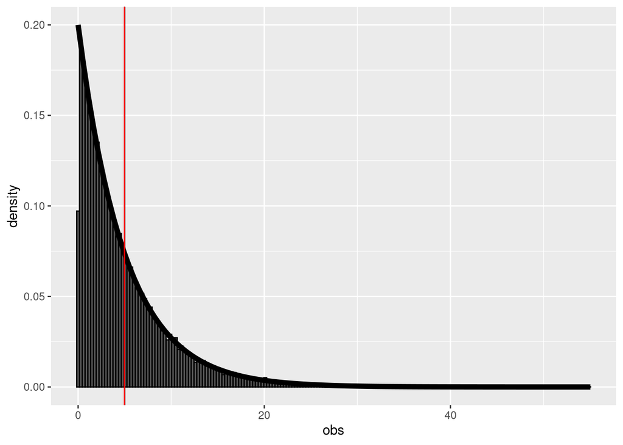

```r
data1 <- data.frame(obs = obs)
g1 <- ggplot(data1, aes(x = obs)) + geom_histogram(binwidth=.3, colour = "black", aes(y = ..density..))
g1 <- g1+ stat_function(fun = dexp, size = 2, args = list(rate=0.2))
g1 <- g1 + geom_vline(xintercept = 5, color  = "black") + geom_vline(xintercept = mean(mns), color = "red")
g1
```

We see that the average of our sample means $\bar X$ is very close the theoretical mean $\mu = 5$, as expected. Their line markers overlap and are essentially indisguishable, so we zoom in around the mean to see the separation:

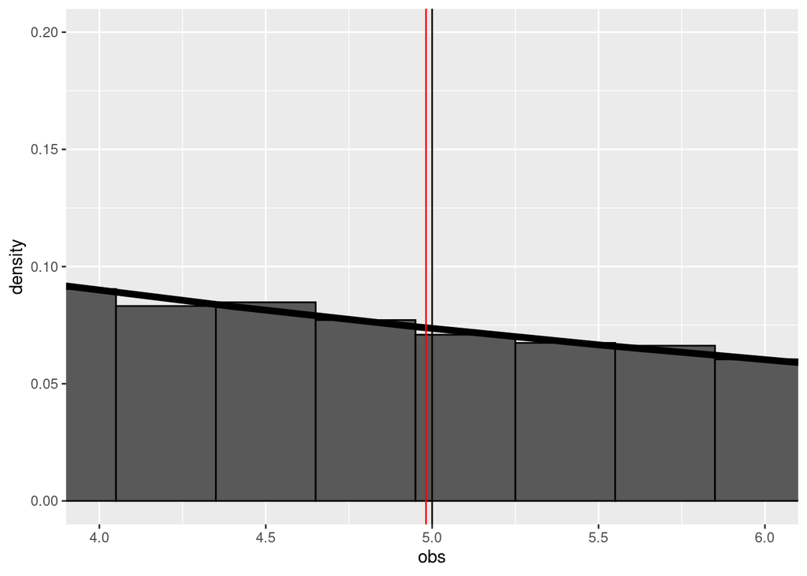

```r
g1 + coord_cartesian(xlim=c(4,6))
```

### Sample Variance vs Theoretical Variance

Recall from the CLT that our sample distribution is approximately $N(\mu, \sigma^2 / n)$. So, we should also be able to estimate the population standard deviation from the calculated sample standard deviation. We expect a sample variance of
$$S^2 \approx \sigma^2/n ~ \Longrightarrow ~ \sigma \approx \sqrt{40S^2}.$$
In this case, there isn’t a convenient graphical way to compare the sample and theoretical variances, so we simply compute the value using the var function in R:

```r
sqrt(40*var(mns))
```

```
## [1] 4.995671
```

This is very close to the known standard deviation $\sigma - 5$.

### The Sample Distribution

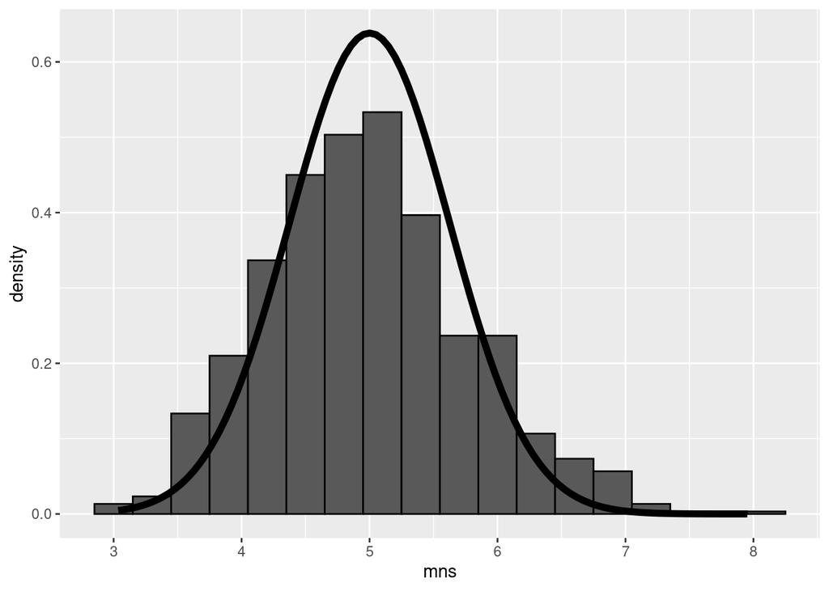

```r
data3 <- data.frame(means = mns)
g3 <- ggplot(data3, aes(x = mns)) + geom_histogram(binwidth=.3, colour = "black", aes(y = ..density..))
g3 + stat_function(fun = dnorm, size = 2, args = list(mean = 5, sd = 25/40))
```

We see that our data seems to roughly approximate the distribution given by the curve, as the CLT predicts. We expect that as we include more observations in each sample, our sample distribution should converge to a better approximation of a normal distribution.

## The ToothGrowth dataset

Next, we want to perform a basic exploratory data analysis on the ToothGrowth dataset which looks at the length of the odontoblasts in 60 guinea pigs given varying doses (0.5, 1, and 2 mg/day) of Vitamin C via two different delivery methods (OJ or VC). First, we look at the summary of the dataset:

```r
data("ToothGrowth")
data <- data.frame(len = ToothGrowth$len, supp = ToothGrowth$supp, dose = as.factor(ToothGrowth$dose))
summary(data)
```

```
##       len        supp     dose
##  Min.   : 4.20   OJ:30   0.5:20
##  1st Qu.:13.07   VC:30   1  :20
##  Median :19.25           2  :20
##  Mean   :18.81
##  3rd Qu.:25.27
##  Max.   :33.90
```

We see that number of observations is divided evenly among each dose and delivery method and that the observed tooth lengths range from 4.2 to 33.9. Furthermore, the observations are cleanly divided among the administration methods and dosage amounts (30/20 each respectively).

## A Quick Look at the Data

The purpose of this data is to look at the effects of dosage and delivery methods on observed tooth growth, so before performing any tests, lets take a look at the data:

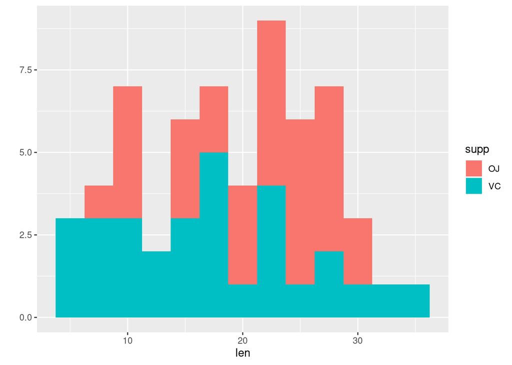

```r
qplot(len, data = data, fill = supp, binwidth = 2.5)
```

From this it appears like the way that the dose is adminstered seems to have an effect. The juice doses tends to have larger values, while the vitamin doses have a wide spread but cluster more at the lower values. We can do a similar thing with the dosages:

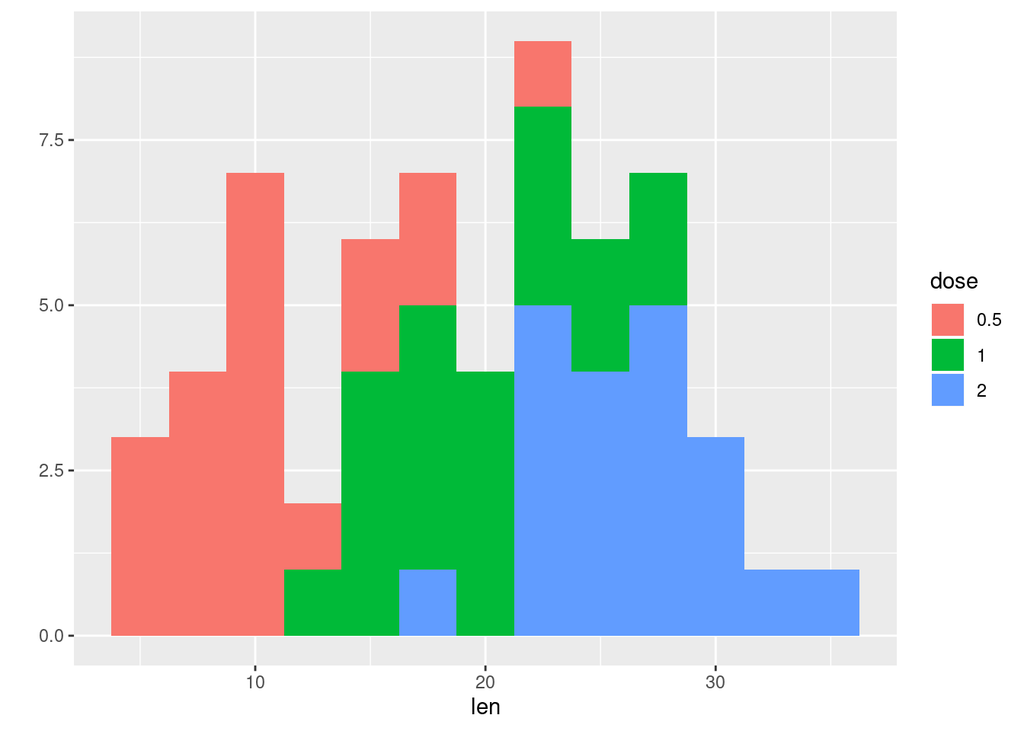

```r
qplot(len, data = data, fill = dose, binwidth = 2.5)
```

This has a more pronounced visible separation with the higher doses corresponding to higher recorded lengths.

### Comparing Method of Delivery

Now, we want to perform some statistical analyses. The natural null hypothesis to test against is that increasing the dosage and changing the delivery method has no effect on tooth growth. First, we consider the method of administration, since we have no particular reason to suspect that one method is better than the other, we use the default two-sided t-test:

```r
suppt <- t.test(len ~ supp, data = data, paired = FALSE)
suppt
```

```
##
##  Welch Two Sample t-test
##
## data:  len by supp
## t = 1.9153, df = 55.309, p-value = 0.06063
## alternative hypothesis: true difference in means is not equal to 0
## 95 percent confidence interval:
##  -0.1710156  7.5710156
## sample estimates:
## mean in group OJ mean in group VC
##         20.66333         16.96333
```

From this we see that the we are testing the null hypothesis that there is no difference in the means against the alternative hypothesis that the difference in the means is not zero. The calculated 95% confidence interval for the difference of the means is $(-0.17,7.57)$, which does contain $0$, so we cannot reject the null hypothesis. However, it is worth noting that our confidence interval barely contains $0$. In fact, the p-value for observing the difference in means for each group is $p = .06$, meaning there is only a 6% chance to see such a separation under the null hypothesis. It would be worthwhile to explore this further, as we only very narrowly fail to reject the null hypothesis.

### Comparing Dosages

Next, we want to compare the low and middle dosages to see if their means are likely to be different:

```r
lowmid <- subset(data, dose %in% as.factor(c(0.5,1)))
lowt <- t.test(len ~ dose, data = lowmid, paired = FALSE, var.equal = FALSE)
lowt
```

```
##
##  Welch Two Sample t-test
##
## data:  len by dose
## t = -6.4766, df = 37.986, p-value = 1.268e-07
## alternative hypothesis: true difference in means is not equal to 0
## 95 percent confidence interval:
##  -11.983781  -6.276219
## sample estimates:
## mean in group 0.5   mean in group 1
##            10.605            19.735
```

We see that the 95% confidence interval for the difference in the observed means for each low (0.5 mg/day) and middle (1 mg/day) dosages is (-11,-6) which does not contain 0. Furthermore, the p-value for observed the calculated difference of the mean under the null hypothesis is very small (~ $10^{-7}$), so we are pretty confident in our rejection of the null hypothesis. We do the same for the middle and high dosages:

```r
midhigh <- subset(data, dose %in% as.factor(c(1,2)))
midt <- t.test(len ~ dose, data = midhigh, paired = FALSE, var.equal = FALSE)
midt
```

```
##
##  Welch Two Sample t-test
##
## data:  len by dose
## t = -4.9005, df = 37.101, p-value = 1.906e-05
## alternative hypothesis: true difference in means is not equal to 0
## 95 percent confidence interval:
##  -8.996481 -3.733519
## sample estimates:
## mean in group 1 mean in group 2
##          19.735          26.100
```

We see that the 95% confidence interval for the difference in the observed means for the midsized (1 mg/day) and high (2 mg/day) dosages is (-9.0,-3.7) which does not contain 0. Furthermore, the p-value for observed the calculated difference of the mean under the null hypothesis is very small (~ $10^{-5}$), so again we are confident in our rejection of the null hypothesis.

### Conclusions

In this document, we explored the Central Limit Theorem in practice, showing how sample methods can be used to estimate parameters of the population distribution. In this case, we use 40000 observations from a simulated exponential distribution with $\lambda = 0.2$. By treating this data as 1000 samples containing 40 observation each, we were able to explore the sample distribution. From which we could verify consequences of the CLT including the approximate normality of the sample distribution, as well as estimating the population mean and the variance/standard deviation.

We also looked at the ToothGrowth dataset which explores the effects of dosing Vitamin C on tooth growth in Guinea Pigs. This data looks at the size of the doses (0.5,1,2 mg/day) as well as the method of delivery (juice, vitamin supplement) in a total of 60 observations, hence a relatively small sample size. So we used T-tests to compare the difference in mean growth based on dosage and method of delivery.

When we compared the dosages, we calculated a large difference in the means. We used two T-tests to compare the small and medium dosages as well as the medium and high doses. In both case we were able to confidently reject the null hypothesis that the difference in the means was zeros. Hence, we would concluded that the mean growth is larger for medium doses than small doses and the mean growth is larger for large doses than medium doses.